# General Groundfish Survey ANN Size-Class Model

Adam Kemberling

2020-03-12

```r
#Global knit options
knitr::opts_chunk$set(warning = FALSE, message = FALSE)

# Libraries
library(lubridate)
library(tidyverse)
library(here)
library(keras)
library(caret)
library(UBL)
library(sf)
library(gmRi)
library(vip)
library(pdp)
library(patchwork)
library(recipes)
library(rsample)
library(knitr)
library(suncalc)
```

# Setup - Atlantic Cod

```r
#Set appropriate path to box and conda setup
if(params$pc == TRUE) {
  # MB setup

  user.name <- params$user_name

  mills_path <- shared.path(os.use = "windows", group = "Mills Lab", folder = NULL)
  res_path <- shared.path(os.use = "windows", group = "RES Data", folder = NULL)

} else {

  #File Paths
  mills_path <- shared.path(os.use = "unix", group = "Mills Lab", folder = NULL)
  res_path <- shared.path(os.use = "unix", group = "RES Data", folder = NULL)

  #Conda setup
  reticulate::use_condaenv("rkeras2020")
}



#Helper functions
source(here("code", "model_diagnostic_funs.R"))
source(here("code/data_cleanup_funs.R"))
source(here("code/data_reshaping_funs.R"))

#GGplot theme
theme_set(theme_bw())

#Saving convention for plots
mod_details <- str_replace(str_c(params$common_name, params$small_lim, params$medium_lim), " ", "_")
```

# Load and Clean

## 1. Filter and Pre-Process

```r
# NEFSC bottom trawl
load(str_c(mills_path, "Data/Survdat_Nye_allseason.RData"))


# Stratum Key for filtering specific areas
strata_key <- list(
  "Georges Bank"  = c(1130,1140, 1150, 1160, 1170, 1180, 1190,
                      1200, 1210, 1220, 1230, 1240, 1250, 3560),
  "Gulf of Maine" = c(1260, 1270, 1280, 1290, 1300, 1360, 1370, 1380,
                      1390, 1400, 3580, 3590, 3600, 3610, 3630, 3640, 3650, 3660))

# Pull the strata we want
strata <- c(
  strata_key$`Georges Bank`,
  strata_key$`Gulf of Maine`)

#Filtering
dat <- survdat %>%
  mutate(ID = format(ID, scientific = FALSE)) %>%
  filter(EST_YEAR %in% c(1982:2015),
         SEASON   %in% c("SPRING", "FALL"),
         STRATUM  %in% strata)


# Pull Target Species
species_pull <- species_selection(survey_data = dat, common_name = params$common_name)
cod          <- species_pull$cod
codtow       <- species_pull$codtow


# Pull station info, one row for every unique ID
dat <- dat %>% distinct(ID, .keep_all = TRUE)
```

## 2. Set Size classes

Upper size limit for “small” size-class: 20  
Upper size limit for “medium” size-class: 60

```r
# bin lengths to 3 groups: small <20, medium 20-60, large >60
cod <- cod %>%
  mutate(
    SIZE = ifelse(LENGTH < params$small_lim, "small", "medium"),
    SIZE = ifelse(LENGTH > params$medium_lim,"large", SIZE),
    NUM  = 1
  )


# for each ID, count number of small, medium, and large
x <- cod %>%
  pivot_wider(id_cols = ID, names_from = SIZE, values_from = NUM, values_fn = list(NUM = sum))

# join with codtow
codtow <- left_join(codtow, x, by="ID")

# remove LENGTH, NUMLEN
codtow <- select(codtow, -c(LENGTH, NUMLEN))

# join tows with cod with tows without cod
x <- left_join(dat, codtow, by="ID")

# select columns to keep
x <- select(x, c(1:29,35:43,74,75,76,77,78,88,89,90))

# if COMNAME is NA, fill-in biomass, abundance, small, medium, large with 0
notcod <- which(is.na(x$COMNAME.y))
x$BIOMASS.y[notcod]   <- 0
x$ABUNDANCE.y[notcod] <- 0
x$small[notcod]       <- 0
x$medium[notcod]      <- 0
x$large[notcod]       <- 0

# for tows with cod, fill-in size category abundance NA with 0
x$small[is.na(x$small)]   <- 0
x$medium[is.na(x$medium)] <- 0
x$large[is.na(x$large)]   <- 0
```

## 3. Allocate Biomass to Size Classes

```r
# Allocate abundance/biomass by proportions of each size class
x <- x %>%
  mutate(
    nsmall   = ABUNDANCE.y * small / (small + medium + large),
    nmedium  = ABUNDANCE.y * medium / (small + medium + large),
    nlarge   = ABUNDANCE.y * large / (small + medium + large),
    nsmall   = ifelse(is.na(nsmall) == T, 0, nsmall),
    nmedium  = ifelse(is.na(nmedium) == T, 0, nmedium),
    nlarge   = ifelse(is.na(nlarge) == T, 0, nlarge),
    bsmall   = BIOMASS.y * small / (small + medium + large),
    bmedium  = BIOMASS.y * medium / (small + medium + large),
    blarge   = BIOMASS.y * large / (small + medium + large),
    bsmall   = ifelse(is.na(bsmall) == T, 0, bsmall),
    bmedium  = ifelse(is.na(bmedium) == T, 0, bmedium),
    blarge   = ifelse(is.na(blarge) == T, 0, blarge)
  )
```

## 4. Weight Biomass by Stratum Area for Plot

```r
# bring in strata area
strataarea <- read_csv(str_c(mills_path, "Projects/NSF_CAccel/Data/strata area.csv"),
                       col_types = cols())

strataarea <- select(strataarea, area, stratum)
colnames(x)[25] <- "stratum"
x <- left_join(x, strataarea, by = "stratum")

# column names without .x or .y at the end
colnames(x) <- str_split(string = colnames(x), pattern="[.]", simplify=TRUE)[,1]


# specify prior area columns (statistical area and stratum size area)
colnames(x)[c(30,53)] <- c("STATAREA","STRATUMAREA")

x$AREA <- ifelse(x$stratum %in% strata_key$`Georges Bank`, "GB", "GoM")

# calculate annual area/season/size class mean abundance and biomass within strata
# area: GoM, GB
# season: spring, fall
# size class: small, medium, large
q <- x %>%
  group_by(EST_YEAR,AREA,SEASON,stratum) %>%
  summarise(mnsmall     = mean(nsmall),
            mnmedium    = mean(nmedium),
            mnlarge     = mean(nlarge),
            mnbsmall    = mean(bsmall),
            mnbmedium   = mean(bmedium),
            mnblarge    = mean(blarge),
            STRATUMAREA = mean(STRATUMAREA))

# calculate stratum weights by stratum area
q <- q %>%
  group_by(EST_YEAR, AREA, SEASON) %>%
  mutate(weight = STRATUMAREA / (sum(STRATUMAREA)))

# calculate annual area/season/size class mean abundance and biomass across strata
p <- q %>%
  group_by(EST_YEAR, AREA, SEASON) %>%
  summarise(abundance_small  = weighted.mean(mnsmall, weight),
            abundance_medium = weighted.mean(mnmedium, weight),
            abundance_large  = weighted.mean(mnlarge, weight),
            biomass_small    = weighted.mean(mnbsmall, weight),
            biomass_medium   = weighted.mean(mnbmedium, weight),
            biomass_large    = weighted.mean(mnblarge, weight))

# long format for plots
a <- p %>%
  pivot_longer(
    cols = 4:9,
    names_to = c("type", "size"),
    names_patter = "(.*)_(.*)",
    values_to = "value")
```

# Observed Abundance Timeline

## Raw Totals

```r
#Raw Abundance/Biomass Totals
raw_tots <- x %>%
  group_by(EST_YEAR, AREA, SEASON) %>%
  summarise(nsmall     = sum(nsmall, na.rm = T),
            nmedium    = sum(nmedium, na.rm = T),
            nlarge     = sum(nlarge, na.rm = T),
            bsmall     = sum(bsmall, na.rm = T),
            bmedium     = sum(bmedium, na.rm = T),
            blarge     = sum(blarge, na.rm = T)
            )

p1 <- raw_tots %>%
  pivot_longer(names_to = "size", values_to = "abundance", cols = nsmall:nlarge) %>%
  ggplot(aes(EST_YEAR, abundance, color = size)) +
  geom_line(size = 1) +
  facet_grid(AREA + SEASON ~., scales="free") +
  labs(title = str_c(str_to_title(params$common_name), " - Total Observed Abundance"),
       x = NULL,
       y = "Total Abundance")


p2 <- raw_tots %>%
  pivot_longer(names_to = "size", values_to = "biomass", cols = bsmall:blarge) %>%
  ggplot(aes(EST_YEAR, biomass, color = size)) +
  geom_line(size = 1) +
  facet_grid(AREA + SEASON ~., scales="free") +
  labs(title = str_c(str_to_title(params$common_name), " - Total Observed Biomass"),
       x = NULL,
       y = "Biomass (kg)")

#Export the raw abundance timeline
if(params$save_agg_catch == TRUE) {
  ggsave(
    p1,
    #strat_abundance_timeline,
    filename = here::here("Code", "multi_species_mods", "obs_abundance", str_c(mod_details, ".png")),
    device = "png")
}
```

### Abundance

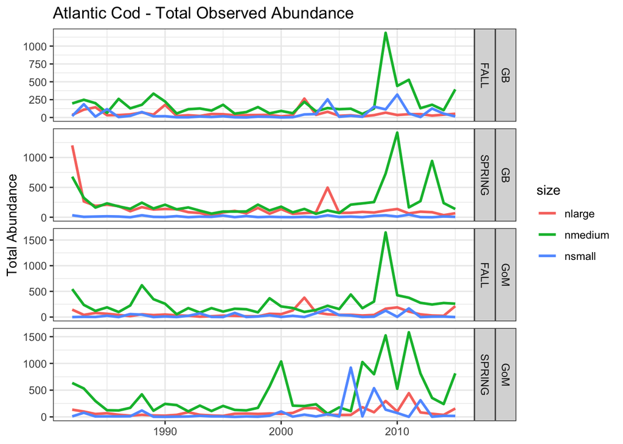

```r
p1
```

### Biomass

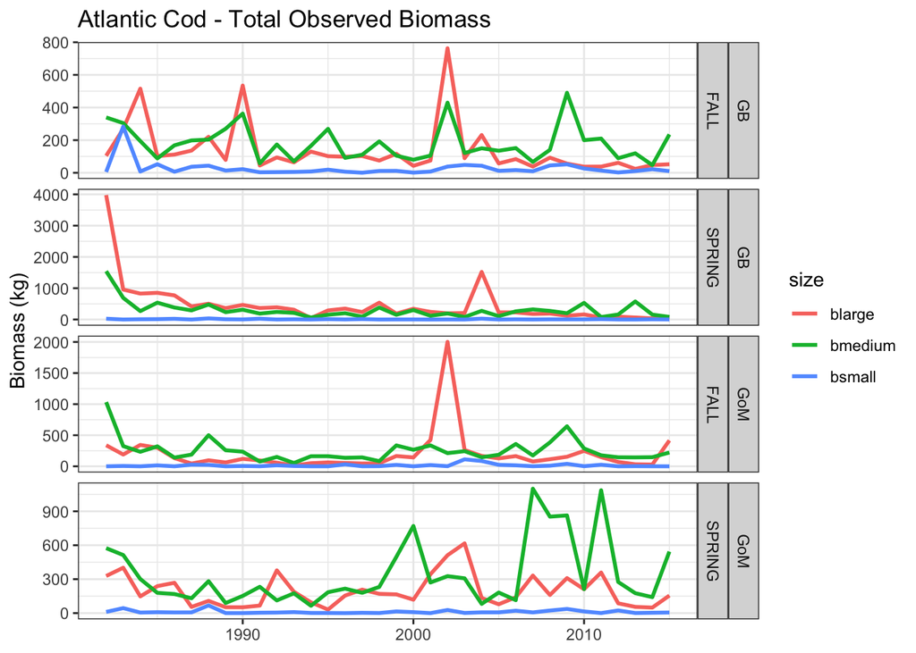

```r
p2
```

## Stratum-Area Weighted

```r
# plot abundance
strat_abundance_timeline <- a %>%
  filter(type == "abundance")%>%
  ggplot(aes(x = EST_YEAR, y = value, group = size, color = size))+
  geom_line(size = 1)+
  facet_grid(AREA + SEASON ~., scales="free") +
  labs(title = str_c(str_to_title(params$common_name), " - Area-Weighted Mean Abundance"),
       x = NULL,
       y = "Mean-Abundance / Station")


#Plot Biomass
strat_biomass_timeline <- a %>%
  filter(type == "biomass")%>%
  ggplot(aes(x = EST_YEAR, y = value, group = size, color = size))+
  geom_line(size = 1)+
  facet_grid(AREA + SEASON ~., scales="free") +
  labs(title = str_c(str_to_title(params$common_name), " - Area-Weighted Mean Biomass"),
       x = NULL,
       y = "Mean-Biomass (kg) / Station")
```

### Abundance

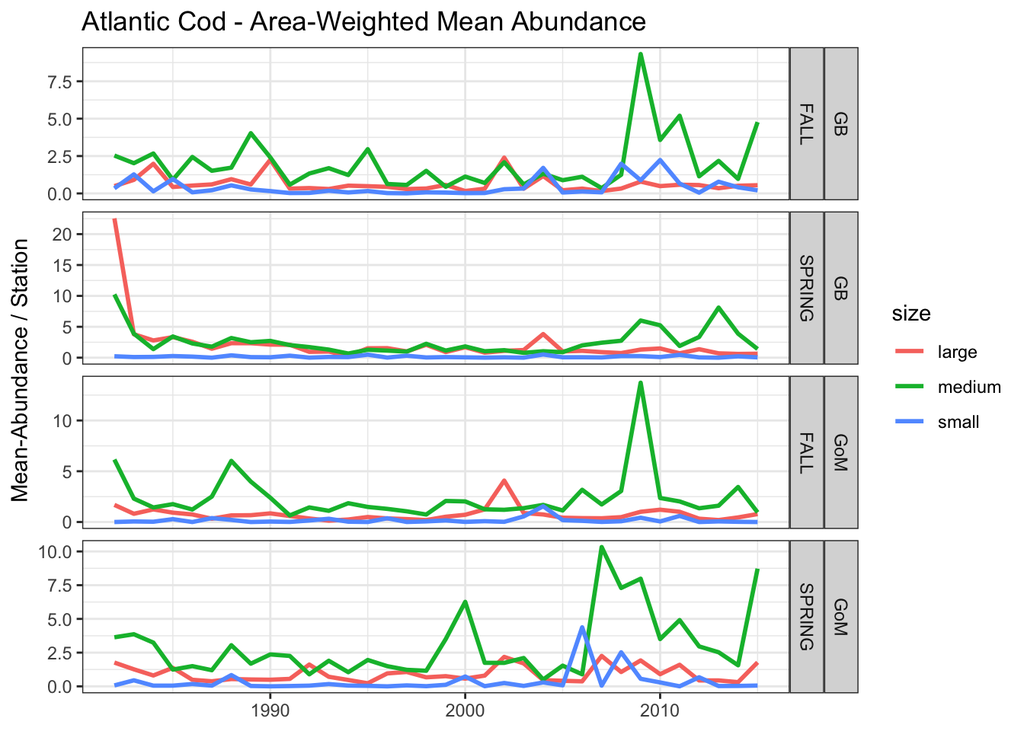

```r
strat_abundance_timeline
```

### Biomass

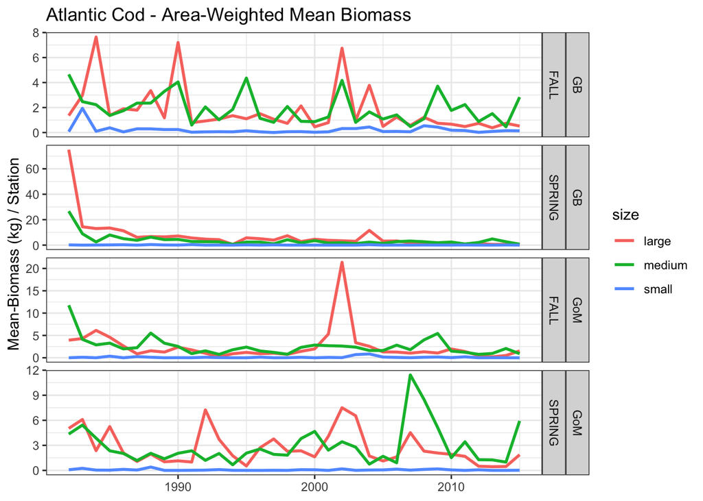

```r
strat_biomass_timeline
```

# SST Anomalies

```r
#Use this code to ignore lagged aggregate catch info
moddf <- x

# now to add in SST for each trawl ID location for year i
trawltemp <- read_csv(str_c(mills_path, "Projects/NSF_CAccel/Data/TrawlTemperatures2.csv"),
                    col_names = c("ID","tempK","tempK10","anom","anom10"), col_types = cols())


# convert Kelvin to Celsius
trawltemp <- trawltemp %>%
  mutate(
    ID = format(ID, scientific = FALSE),
    tempC = tempK - 273.15,
    tempC10 = tempK10 - 273.15) %>%
  select(ID, anom, anom10)
```

# Recipes Data Prep

## 1. Format and Transform Data

Format factor data, log-transform dependent vars. Flag events with abnormally high catches for each size-class, report how many observations share the same predictors (i.e. how uniquely identifiable are the conditions surrounding large catch events).

```r
# join with widedat by ID
survey_data <- left_join(moddf, trawltemp, by = "ID")

#Format factors
survey_data <- survey_data %>%
  mutate(
    SEASON    = factor(SEASON, levels = c("SPRING", "FALL")),
    SVVESSEL  = factor(SVVESSEL),
    AREA      = factor(AREA),
    stratum   = factor(stratum)
  )



#Convert abundance to abundance/area in km2
#1 ST with Albatross = 0.038km2
survey_data <- survey_data %>%
  mutate(
    nsmall = nsmall / 0.0384,
    nmedium = nmedium / 0.0384,
    nlarge = nlarge / 0.0384
  )



#Log transform the abundances
survey_data <- survey_data %>%
  mutate(
    nsmall = log(nsmall + 1),
    nmedium = log(nmedium + 1),
    nlarge = log(nlarge + 1)
  )



#Add date columns here
survey_data <- survey_data %>%
  mutate(date = as.Date(str_c(EST_YEAR, "-", EST_MONTH, "-", EST_DAY), format = "%Y-%m-%d"))


#Time of day
survey_tod <- survey_data %>%
  select(date, lon = DECDEG_BEGLON, lat = DECDEG_BEGLAT)

#Calculate the start and end periods of twilight/night/day
survey_tod <- getSunlightTimes(data = survey_tod, keep = c("dusk", "night", "nauticalDawn", "dawn"))


#Also get moon phases/illumination
survey_moon <- getMoonIllumination(date = survey_tod$date, keep = c("fraction", "phase")) %>%
  select(-date, moon_frac = fraction, moon_phase = phase)

survey_astro <- bind_cols(survey_tod, survey_moon) %>% select(-date)


#Add astrological predictors back in
survey_data <- bind_cols(survey_data, survey_astro)



#Time of Day Flags
#twilight = between dusk and night or between nautical dawn and dawn
#day = dawn to dusk
#night = night to nautical dawn

survey_data <- survey_data %>%
  mutate(
    sta_dattime = ymd_hms(str_c(date, " ", EST_TIME)),
    tod = ifelse(sta_dattime > dusk -days(1) & sta_dattime <= night, "twilight_dusk", NA),
    tod = ifelse(sta_dattime > dusk & sta_dattime <= night + lubridate::days(1), "twilight_dusk", tod),
    tod = ifelse(sta_dattime > nauticalDawn & sta_dattime <= dawn , "twilight_dawn", tod),
    tod = ifelse(sta_dattime > dawn & sta_dattime <= dusk, "day", tod),
    tod = ifelse(sta_dattime > night - lubridate::days(1)  & sta_dattime <= nauticalDawn , "night", tod),
    tod = ifelse(sta_dattime > night  & sta_dattime <= nauticalDawn + lubridate::days(1), "night", tod),
    tod = ifelse(is.na(tod), "twilight_dusk", tod), # these are all times after midnight between dusk/night
    tod = factor(tod)
  ) #count(tod)

#survey_data %>% filter(is.na(tod)) %>% select(sta_dattime, dusk, night, nauticalDawn, dawn)

#Moon Phase Flags
survey_data <- survey_data %>%
  #transmute(
  mutate(
    moon_phase = moon_phase,
    moon_phase_offset = (moon_phase - 0.0625),
    moon_phase_offset = ifelse(moon_phase_offset < 0, 0, moon_phase_offset),
    lunar_phase = moon_phase_offset %/% .125,
    lunar_phase = case_when(
      lunar_phase == 0 ~ "new",
      lunar_phase == 1 ~ "wax_c",
      lunar_phase == 2 ~ "q1",
      lunar_phase == 3 ~ "wax_g",
      lunar_phase == 4 ~ "full",
      lunar_phase == 5 ~ "wane_g",
      lunar_phase == 6 ~ "q3",
      lunar_phase == 7 ~ "wane_c"
    ),
    lunar_phase = factor(lunar_phase)
  )





####  Resampling Thresholds  ####
small_q <- quantile(survey_data$nsmall, 0.98)
medium_q <- quantile(survey_data$nmedium, 0.98)
large_q <- quantile(survey_data$nlarge, 0.98)

survey_data <- survey_data %>%
  mutate(
    big_catch = case_when(
      nsmall >= small_q ~ "many_nsmall",
      nmedium >= medium_q ~ "many_medium",
      nlarge >= large_q ~ "many_large",
      TRUE ~ "typical_low"
    )
  )

####  Dig into resampling data  ####

#What data is resampled in original units
resampled_df <- survey_data %>%
  select(big_catch, nsmall, nmedium, nlarge,
         SEASON, SVVESSEL, tod, lunar_phase, AREA, stratum, anom, anom10) %>%
  mutate(nsmall = (exp(nsmall) - 1) * 0.0384,
         nmedium = (exp(nmedium) - 1) * 0.0384,
         nlarge = (exp(nlarge) - 1) * 0.0384)

resampled_splits <- resampled_df %>% filter(big_catch != "typical_low") %>%
  split(.$big_catch)


resampling_statement <- resampled_splits %>% map_dfr(function(big_catch_split){

  n_big_catches <- nrow(big_catch_split)
  same_cond <- inner_join(resampled_df, big_catch_split,
                          by = c("SEASON", "SVVESSEL", "tod", "lunar_phase", "AREA",
                                 "stratum", "anom", "anom10"))
  n_same_cond <- nrow(same_cond)
  n_low_catch <- n_same_cond - n_big_catches

  statement <- str_c(n_low_catch, " low catch stations had the same exact predictors as the ",
                     n_big_catches, " stations of excessively high catch we resampled.")

  return(tibble("Size" = NA, "Resampling Statement" = statement))

})

resampling_statement$Size <- factor(c("Large", "Medium", "Small"), levels = c("Small", "Medium", "Large"))
resampling_statement %>% arrange(Size) %>% knitr::kable()
```

| Size | Resampling Statement |
| --- | --- |
| Small | 31 low catch stations had the same exact predictors as the 184 stations of excessively high catch we resampled. |
| Medium | 22 low catch stations had the same exact predictors as the 128 stations of excessively high catch we resampled. |
| Large | 50 low catch stations had the same exact predictors as the 146 stations of excessively high catch we resampled. |

## 2. Split Training and Testing Set

Split by proportion, or by time.

```r
#Split training and testing data
#Not enough data to stratify
#survey_data <- survey_data %>% mutate(kfold_strata = str_c(EST_YEAR))
#survey_data_split <- initial_split(survey_data, prop = (4/5), strata = "kfold_strata")

#non-stratified split
survey_data_split <- initial_split(survey_data, prop = (4/5))

## Or... Leave out last few years
#survey_data_split <- initial_time_split(survey_data, prop = (30/34))

#Split them
survey_training <- training(survey_data_split)
survey_testing <- testing(survey_data_split)
```

## 3. Model Recipe

Pulls the variables we want in the model for any processing steps and standardizaitons.

```r
#the code here is written really dumb so I can easily see that predictors by category at a glance
model_recipe <-  recipe(
  #--Outcomes--
  #small_per_km + medium_per_km + large_per_km ~
  nsmall + nmedium + nlarge ~
    #--Predictors--
    #Temporal Information
    SEASON + SVVESSEL + tod + lunar_phase +
    #Spatial Information
    AREA + stratum + #DECDEG_BEGLAT + DECDEG_BEGLON +
    # #Tow Information
    TOWDUR + BOTTEMP + #SURFTEMP + AVGDEPTH +
    #SST and SST ten days prior
    anom + anom10 +
    #Large catch resampling flag
    big_catch,

    #Sea State
    #AIRTEMP + BAROPRESS + WINDDIR + WINDDIR + WAVEHGT,


  #--Data--
  data = survey_training)
```

## 4. Recipe Summary

```r
summary(model_recipe) %>% knitr::kable()
```

| variable | type | role | source |
| --- | --- | --- | --- |
| SEASON | nominal | predictor | original |
| SVVESSEL | nominal | predictor | original |
| tod | nominal | predictor | original |
| lunar_phase | nominal | predictor | original |
| AREA | nominal | predictor | original |
| stratum | nominal | predictor | original |
| TOWDUR | numeric | predictor | original |
| BOTTEMP | numeric | predictor | original |
| anom | numeric | predictor | original |
| anom10 | numeric | predictor | original |
| big_catch | nominal | predictor | original |
| nsmall | numeric | outcome | original |
| nmedium | numeric | outcome | original |
| nlarge | numeric | outcome | original |

## 5. Set Recipe Steps

```r
# Standard Recipe
recipe_steps <- model_recipe %>%

  # 1. Dealing with NA values
  #step_meanimpute(all_numeric(), -all_outcomes()) %>%
  step_naomit(everything()) %>%

  # 2. Convert Factor Variables into one-hot dummy variables
  step_dummy(all_nominal(), -big_catch) %>%

  # 3. Re-scale numeric values to range 0-1
  step_range(all_numeric(),  min = 0, max = 1, -all_outcomes())

recipe_steps
```

```
## Data Recipe
##
## Inputs:
##
##       role #variables
##    outcome          3
##  predictor         11
##
## Operations:
##
## Removing rows with NA values in everything
## Dummy variables from all_nominal, -, big_catch
## Range scaling to [0,1] for all_numeric, -, all_outcomes()
```

```r
# Upsampling Recipe
upsample_recipe <- recipe_steps %>%

  # 4. Up-sample rare catch events
  step_upsample(big_catch, over_ratio = 0.5, seed = 123, skip = FALSE)
```

## 6. Preparing the recipe

```r
prepped_recipe <- prep(recipe_steps, training = survey_training)
prepped_recipe
```

```
## Data Recipe
##
## Inputs:
##
##       role #variables
##    outcome          3
##  predictor         11
##
## Training data contained 7326 data points and 1580 incomplete rows.
##
## Operations:
##
## Removing rows with NA values in everything
## Dummy variables from SEASON, SVVESSEL, tod, lunar_phase, AREA, stratum [trained]
## Range scaling to [0,1] for TOWDUR, BOTTEMP, anom, anom10, ... [trained]
```

```r
prepped_upsample_recipe <- prep(upsample_recipe, training = survey_training)
prepped_upsample_recipe
```

```
## Data Recipe
##
## Inputs:
##
##       role #variables
##    outcome          3
##  predictor         11
##
## Training data contained 7326 data points and 1580 incomplete rows.
##
## Operations:
##
## Removing rows with NA values in everything
## Dummy variables from SEASON, SVVESSEL, tod, lunar_phase, AREA, stratum [trained]
## Range scaling to [0,1] for TOWDUR, BOTTEMP, anom, anom10, ... [trained]
## Up-sampling based on big_catch [trained]
```

## 7. Bake Recipe

```r
train_preprocessed <- bake(prepped_recipe, survey_training) %>% select(-big_catch)
train_upsampled    <- bake(prepped_upsample_recipe, survey_training) %>% select(-big_catch)
test_preprocessed  <- bake(prepped_recipe, survey_testing) %>% select(-big_catch)
```

# Keras Model Setup

## 1. Data in

```r
# Keras model setup

####  Training

# Log Abundance
train_labels_raw <- train_preprocessed %>% select(nsmall, nmedium, nlarge) %>% as.matrix()
train_data_raw   <- train_preprocessed %>% select(-nsmall, -nmedium, -nlarge) %>% as.matrix()


####  Upsampled Training

# Log Abundance
train_labels <- train_upsampled %>% select(nsmall, nmedium, nlarge) %>% as.matrix()
train_data   <- train_upsampled %>% select(-nsmall, -nmedium, -nlarge) %>% as.matrix()


####  Testing

# Log Abundance
test_labels <- test_preprocessed %>% select(nsmall, nmedium, nlarge) %>% as.matrix()
test_data   <- test_preprocessed %>% select(-nsmall, -nmedium, -nlarge) %>% as.matrix()
```

## 2. Define Model Structure

```r
# input layer
inputs <- layer_input(shape = dim(train_data)[2])

# two hiddent layers with dropout
hidden <- inputs %>%
  layer_dense(units = dim(train_data)[2],
              activation = "relu",
              kernel_initializer = "he_normal",
              bias_initializer = "he_uniform") %>%
  layer_dropout(0.2) %>%
  layer_dense(units = dim(train_data)[2],
              activation = "relu",
              kernel_initializer = "he_normal",
              bias_initializer = "he_uniform") %>%
  layer_dropout(0.2)

# output for small size class
small_output <- hidden %>% layer_dense(units = 1, name = "sml_out")

# output for medium size class
medium_output <- hidden %>% layer_dense(units = 1, name = "med_out")

# output for large size class
large_output <- hidden %>% layer_dense(units = 1, name = "lrg_out")

# create model
model <- keras_model(inputs = inputs,
                     outputs = c(small_output, medium_output, large_output))

# compile
model %>% compile(optimizer = "adam",
                  loss = "mse",
                  metrics = "mse",
                  loss_weights = list(
                    sml_out = 1,
                    med_out = 1,
                    lrg_out = 1))

# summary
model %>% summary()
```

```
## Model: "model"
## ___________________________________________________________________________
## Layer (type)            Output Shape     Param #  Connected to
## ===========================================================================
## input_1 (InputLayer)    [(None, 49)]     0
## ___________________________________________________________________________
## dense (Dense)           (None, 49)       2450     input_1[0][0]
## ___________________________________________________________________________
## dropout (Dropout)       (None, 49)       0        dense[0][0]
## ___________________________________________________________________________
## dense_1 (Dense)         (None, 49)       2450     dropout[0][0]
## ___________________________________________________________________________
## dropout_1 (Dropout)     (None, 49)       0        dense_1[0][0]
## ___________________________________________________________________________
## sml_out (Dense)         (None, 1)        50       dropout_1[0][0]
## ___________________________________________________________________________
## med_out (Dense)         (None, 1)        50       dropout_1[0][0]
## ___________________________________________________________________________
## lrg_out (Dense)         (None, 1)        50       dropout_1[0][0]
## ===========================================================================
## Total params: 5,050
## Trainable params: 5,050
## Non-trainable params: 0
## ___________________________________________________________________________
```

## 3. Set Call-back options

```r
# Display training progress by printing a single dot for each completed epoch.
print_dot_callback <- callback_lambda(
  on_epoch_end = function(epoch, logs) {
    if (epoch %% 80 == 0) cat("\n")
    cat(".")
  }
)

# Stop training if the validation score doesn't improve
# The patience parameter is the amount of epochs to check for improvement.
early_stop <- callback_early_stopping(monitor = "loss", patience = 25)
```

## 4. Train Model

```r
# train model and store training progress learning curves (no validation)
history <- model %>%
  fit(train_data,
      y = list(
        sml_out = train_labels[,1],
        med_out = train_labels[,2],
        lrg_out = train_labels[,3]),
      callbacks = list(print_dot_callback, early_stop),
      epochs = 200,
      verbose = 0)
```

```
##
## ................................................................................
## ................................................................................
## ....................................
```

```r
# model performance on test set
eval <- evaluate(model,
                 test_data,
                 y = list(
                   sml_out = test_labels[,1],
                   med_out = test_labels[,2],
                   lrg_out = test_labels[,3]),
                 verbose = 0)

cbind(eval) %>% kable()
```

|  | eval |
| --- | --- |
| loss | 10.2055912865679 |
| sml_out_loss | 1.46211850643158 |
| med_out_loss | 4.77228307723999 |
| lrg_out_loss | 3.91413950920105 |
| sml_out_mse | 1.48238086700439 |
| med_out_mse | 4.78833103179932 |
| lrg_out_mse | 3.93488025665283 |

# Save Model

```r
# Save ANN model
save_model_hdf5(object = model,
                filepath = here("Code", "multi_species_mods", "keras_models", str_c(mod_details, ".h5")))


####  training and Testing Data  ####
write_csv(train_preprocessed,
          path = here::here("Code", "multi_species_mods", "train_dat", str_c(mod_details, "train.csv")),
          col_names = TRUE)

write_csv(test_preprocessed,
          path = here::here("Code", "multi_species_mods", "test_dat", str_c(mod_details, "test.csv")),
          col_names = TRUE)
```

# Load Model Run(s)

```r
# load saved model
model <- load_model_hdf5(
  filepath = here("Code", "multi_species_mods", "keras_models", str_c(mod_details, ".h5"))
  )

# load training
training <- read_csv(here::here("Code", "multi_species_mods", "train_dat", str_c(mod_details, "train.csv")),
                   col_types = cols(),
                   guess_max = 1e5)

# load testing
testing <- read_csv(here::here("Code", "multi_species_mods", "test_dat", str_c(mod_details, "test.csv")),
                   col_types = cols(),
                   guess_max = 1e5)
```

# Make Predictions with Test Data

```r
# Make predictions
test_predictions <- model %>% predict(test_data)
test_predictions <- cbind(test_predictions[[1]],
                          test_predictions[[2]],
                          test_predictions[[3]])
# Undo log-transformation
test_predictions <- round(exp(test_predictions) -1, 2)
true_labels      <- round(exp(test_labels) -1, 2)

# combine observed values and predictions
results <- data.frame(
  observed_small   = as.numeric(true_labels[,1]),
  observed_medium  = as.numeric(true_labels[,2]),
  observed_large   = as.numeric(true_labels[,3]),
  predicted_small  = as.numeric(test_predictions[,1]),
  predicted_medium = as.numeric(test_predictions[,2]),
  predicted_large  = as.numeric(test_predictions[,3]))
```

# Model Diagnostics

```r
#Remember that you omitted NA's from survey testing set
#Pull the predictor columns you dropped NA values on
survey_testing <- survey_testing %>%
  select(ID, EST_YEAR, SEASON, SVVESSEL,
         tod, lunar_phase,
         AREA, stratum, TOWDUR, BOTTEMP,
         anom, anom10, big_catch,
         nsmall, nmedium, nlarge) %>%
  drop_na()

# reshape prediction results for time series plots
results$ID <- survey_testing$ID

#Pull general meta-data needed for joining and plotting
survey_meta <- survey_testing %>% select(ID, EST_YEAR, SEASON, SVVESSEL, AREA, stratum)
datdat <- left_join(survey_meta, results, by = "ID")

#datdat contains the testing predictions and the observed values
#as well as the station information that goes with them

#also want stratum area
strataarea <- select(strataarea, stratum, area) %>% mutate(stratum = factor(stratum))
datdat <- datdat %>% left_join(strataarea, by = "stratum")
```

## 1. Testing Data - Obs/Pred Timeline

The following figures show the prediction accuracy of the model when applied to the testing data. “Observed” values are what the actual numbers were at stations from the testing data, and “predicted” values are what the model inferred for those stations.

```r
#Factor Summaries
model_summs <- datdat %>%
  group_by(year = EST_YEAR, area = AREA, season = SEASON) %>%
  summarise(
    psmall  = mean(predicted_small, na.rm = T),
    pmedium = mean(predicted_medium, na.rm = T),
    plarge  = mean(predicted_large, na.rm = T),
    osmall  = mean(observed_small, na.rm = T),
    omedium = mean(observed_medium, na.rm = T),
    olarge  = mean(observed_large, na.rm = T)
  ) %>%
  pivot_longer(cols = 4:9, names_to = c("type", "size"), values_to = "abundance", names_sep = 1) %>%
  mutate(size = factor(size, levels = c("small", "medium", "large")),
         type = ifelse(type == "p", "Predicted", "Observed"))


if(params$save_agg_catch == TRUE) {
  write_csv(model_summs,
            here::here("Code", "multi_species_mods", "seasonal_model_inputs", str_c(mod_details, ".csv")),
            col_names = T)
}
```

### Gulf of Maine

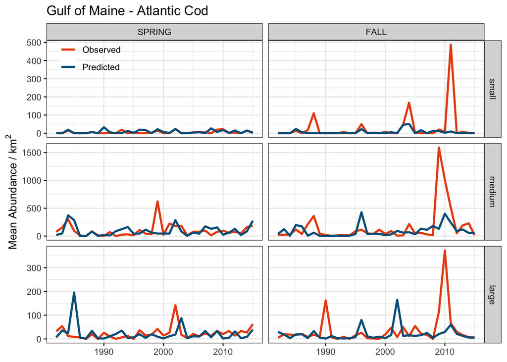

```r
# GoM
(GOM_test_tl <- model_summs %>%
  filter(area == "GoM") %>%
  ggplot(aes(x = year, y = abundance, group = type, color = type)) +
    geom_line(size = 1) +
    scale_color_gmri(palette = "mixed") +
    facet_grid(size~ season, scales = "free") +
    labs(title = str_c("Gulf of Maine - ", str_to_title(params$common_name)),
         x = NULL,
         y = expression(paste("Mean Abundance / km" ^2))) +
    theme(legend.position = c(0.1, 0.95),
          legend.background = element_blank(),
          legend.title = element_blank()))
```

```r
#Export Plot
ggsave(GOM_test_tl,
         filename = here("Code", "multi_species_mods", "testdat_timelines", str_c(mod_details, "GOM.png")),
         device = "png")
```

### Georges Bank

[figure not shown]

```r
# GB
(GB_test_tl <- model_summs %>%
  filter(area == "GB") %>%
  ggplot(aes(x = year, y = abundance, group = type, color = type)) +
  geom_line(size = 1) +
  scale_color_gmri(palette = "mixed") +
  facet_grid(size ~ season, scales = "free") +
   labs(title = str_c("Gulf of Maine - ", str_to_title(params$common_name)),
         x = NULL,
         y = expression(paste("Mean Abundance / km" ^2))) +
  theme(legend.position = c(0.1, 0.95),
        legend.background = element_blank(),
        legend.title = element_blank()))
```

```r
#Export plot
ggsave(GB_test_tl,
         filename = here("Code", "multi_species_mods", "testdat_timelines", str_c(mod_details, "GB.png")),
         device = "png")
```

## 2. Aggregate Survey Abundances

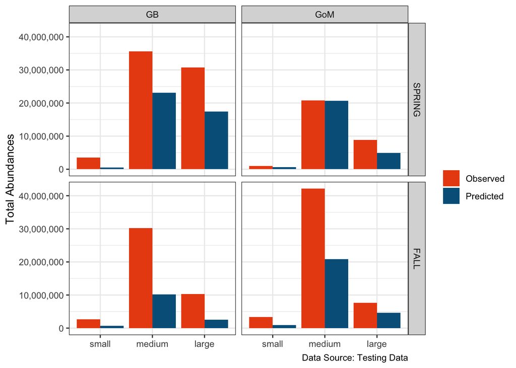

```r
#Total Biomass Estimates from test data and test data predictions
total_abundance_testing <- datdat %>%
  mutate(
    psmall  = predicted_small * area,
    pmedium = predicted_medium * area,
    plarge  = predicted_large * area,
    osmall  = observed_small * area,
    omedium = observed_medium * area,
    olarge  = observed_large * area
  ) %>%
  group_by(area = AREA, season = SEASON) %>%
  summarise(
    psmall  = sum(psmall, na.rm = T),
    pmedium = sum(pmedium, na.rm = T),
    plarge  = sum(plarge, na.rm = T),
    osmall  = sum(osmall, na.rm = T),
    omedium = sum(omedium, na.rm = T),
    olarge  = sum(olarge, na.rm = T)
  ) %>%
  pivot_longer(cols = psmall:olarge,
               names_to = c("type", "size"),
               values_to = "Total Abundance",
               names_sep = 1) %>%
  mutate(size = factor(size, levels = c("small", "medium", "large")),
         type = ifelse(type == "p", "Predicted", "Observed"))

agg_catch_plot <- total_abundance_testing %>%
  ggplot(aes(size, `Total Abundance`, fill = type)) +
  geom_col(position = "dodge") +
  facet_grid(season ~ area) +
  labs(
    y = "Total Abundances",
    x = NULL,
    caption = "Data Source: Testing Data") +
  scale_fill_gmri(palette = "mixed") +
  scale_y_continuous(labels = scales::comma_format()) +
  guides(fill = guide_legend("")) +
  theme()

agg_catch_plot
```

```r
# #Factor Summaries - no longer makes sense using CPUE instead of station abundance
# testing_abundances <- datdat %>%
#   group_by(area = AREA, season = SEASON) %>%
#   summarise(
#     psmall  = sum(predicted_small, na.rm = T),
#     pmedium = sum(predicted_medium, na.rm = T),
#     plarge  = sum(predicted_large, na.rm = T),
#     osmall  = sum(observed_small, na.rm = T),
#     omedium = sum(observed_medium, na.rm = T),
#     olarge  = sum(observed_large, na.rm = T)
#   ) %>%
#   pivot_longer(cols = psmall:olarge,
#                names_to = c("type", "size"),
#                values_to = "abundance",
#                names_sep = 1) %>%
#   mutate(size = factor(size, levels = c("small", "medium", "large")),
#          type = ifelse(type == "p", "Predicted", "Observed"))
#
#
# agg_catch_plot <- testing_abundances %>%
#   ggplot(aes(size, abundance, fill = type)) +
#   geom_col(position = "dodge") +
#   facet_grid(season ~ area) +
#   labs(y = "Total Abundance - Testing Data", x = NULL) +
#   scale_fill_gmri(palette = "mixed") +
#   guides(fill = guide_legend("")) +
#   theme()
#
#
# agg_catch_plot

#Export plot
ggsave(agg_catch_plot,
         filename = here("Code", "multi_species_mods", "agg_catch", str_c(mod_details, ".png")),
         device = "png")
```

## 3. Strata Predictions

```r
####  Load Model Prediction Data  ####
# datdat  <- read_csv(here("predictions20132015.csv"), col_types = cols(), guess_max = 1e6)
mod_summs_sf <- strata_summs(datdat)


#Multiply catch/area by stratum area to get total biomass in stratum
#also want stratum area
strataarea <- select(strataarea, stratum, area) %>% mutate(stratum = as.character(stratum))
mod_summs_sf <- mod_summs_sf %>% left_join(strataarea, by = c("STRATA" = "stratum")) %>%
  mutate(stratum_abundance = abundance * area)
```

### Observed and Predicted

```r
stratum_plots <- obs_pred_plot(mod_summs_sf, size_facets = FALSE)
```

#### Small

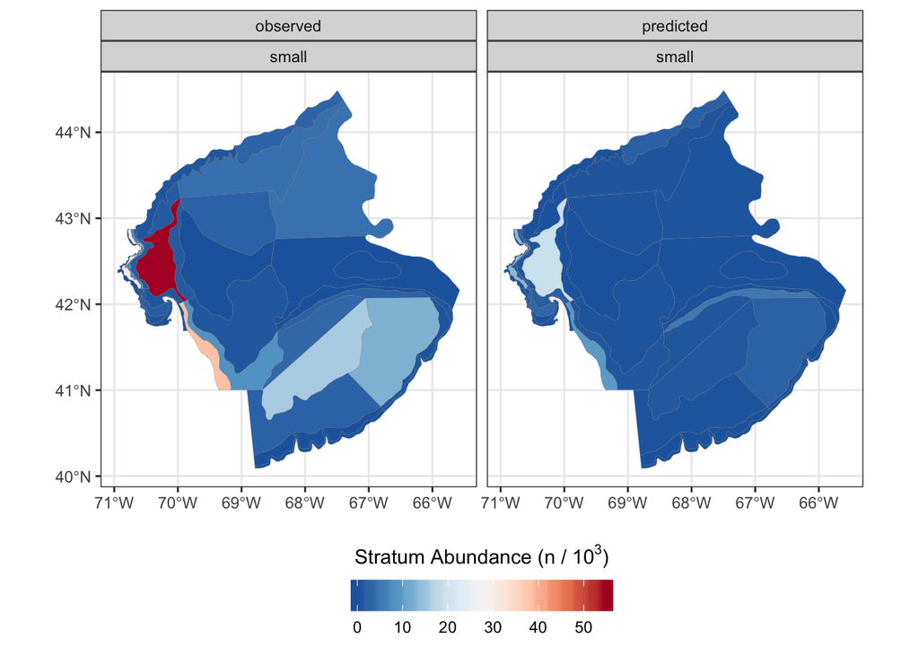

```r
stratum_plots$small
```

#### Medium

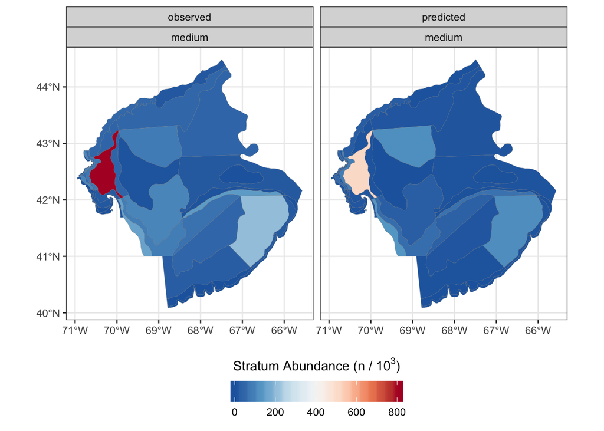

```r
stratum_plots$medium
```

#### Large

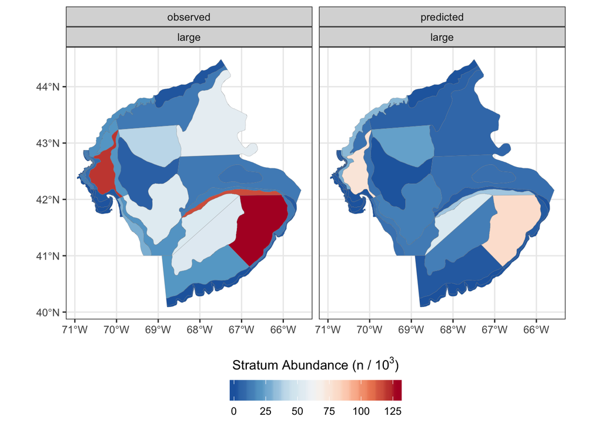

```r
stratum_plots$large
```

### Prediction Differences

```r
strata_diff_plots <- strata_diffs_plot(mod_summs_sf, size_facets = FALSE)
```

#### Small

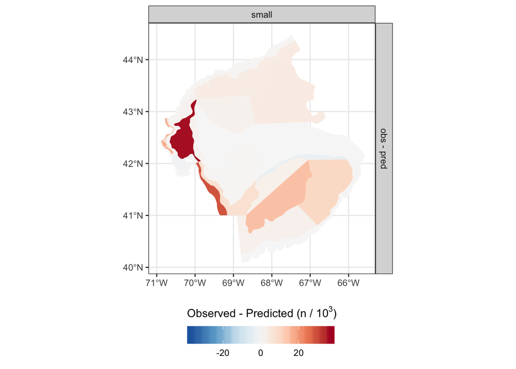

```r
strata_diff_plots$small
```

#### Medium

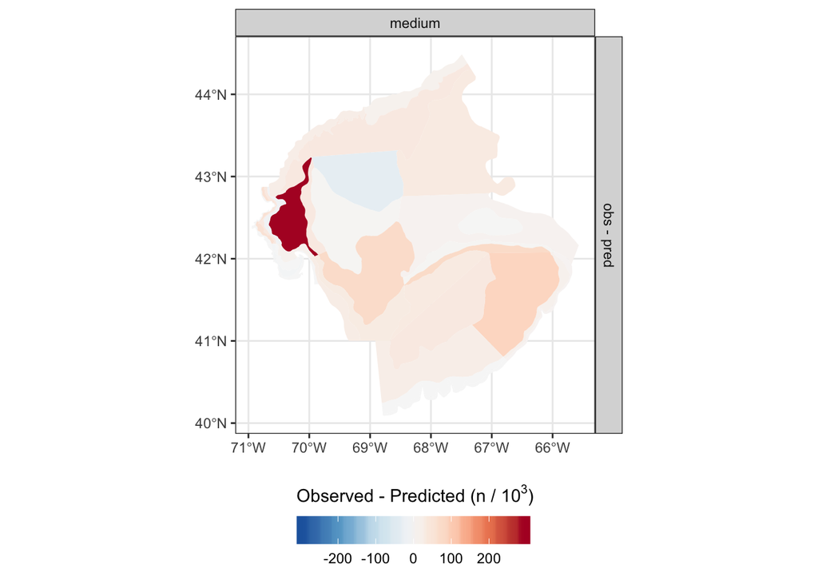

```r
strata_diff_plots$medium
```

#### Large

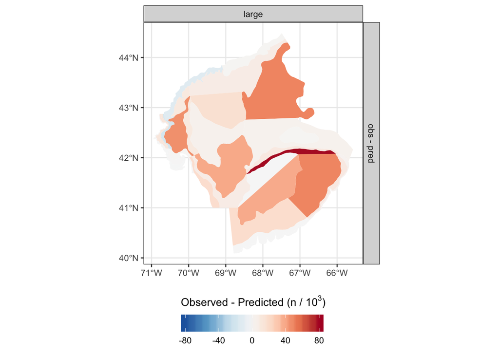

```r
strata_diff_plots$large
```

```r
# Save Plots
if(params$save_maps == TRUE) {
  #Observed and Predicted Values
  ggsave(stratum_plots$small,
         filename = here("Code", "multi_species_mods", "strata_plots", "obs_pred", str_c(mod_details, "small.png")),
         device = "png")
  ggsave(stratum_plots$medium,
         filename = here("Code", "multi_species_mods", "strata_plots", "obs_pred", str_c(mod_details, "medium.png")),
         device = "png")
  ggsave(stratum_plots$large,
         filename = here("Code", "multi_species_mods", "strata_plots", "obs_pred", str_c(mod_details, "large.png")),
         device = "png")
  #Difference Plots
  ggsave(strata_diff_plots$small,
         filename = here("Code", "multi_species_mods", "strata_plots", "diffs", str_c(mod_details, "small.png")),
         device = "png")
  ggsave(strata_diff_plots$medium,
         filename = here("Code", "multi_species_mods", "strata_plots", "diffs", str_c(mod_details, "medium.png")),
         device = "png")
  ggsave(strata_diff_plots$large,
         filename = here("Code", "multi_species_mods", "strata_plots", "diffs", str_c(mod_details, "large.png")),
         device = "png")
}
```

## 4. Variable importance plots

```r
# from https://bgreenwell.github.io/pdp/articles/pdp-example-tensorflow.html

# vip randomly permutes the values of each feature and records the drop in training performance

# prediction function wrapper, two arguments: object (the fitted model) and newdata
# The function needs to return a vector of predictions (one for each observation)
pred_wrapper <- function(object, newdata){
  predict(object, x = as.matrix(newdata))[[2]]%>% # list 2 is medium size class
  as.vector()
}



# Permutation-based VIP for the fitted network

#Variable importance for the three size-classes
size_classes <- c("small" = "nsmall", "medium" = "nmedium", "large" = "nlarge")


#Map the plot function for each size class
size_class_vip <- imap(size_classes, function(size_classes, label){
  p1 <- vip(
    object = model,                          # fitted model
    method = "permute",                      # permutation-based VI scores
    num_features = 10,                       # plots top 10 features
    pred_wrapper = pred_wrapper,             # user-defined prediction function
    train = as.data.frame(train_data) ,      # training data
    target = train_labels[, size_classes],   # response values used for training (column 2 is medium size class)
    metric = "mse",                          # evaluation metric
    progress = "none")                       # request a text-based progress bar


  # Return Plot
  return(p1 + labs(subtitle = str_c(params$common_name, " - ", label)))
})


vsmall <- size_class_vip$small  + labs(x = "")
vmed   <- size_class_vip$medium  + labs(x  = NULL)
vlarge <- size_class_vip$large

vip_all <- vsmall / vmed / vlarge
vip_all

# Save Size Class VIP Plot
if(params$save_vip == TRUE) {
  ggsave(vip_all,
         filename = here("Code", "multi_species_mods", "vip_plots", str_c(mod_details, "VIP.png")),
         device = "png")
  }
```

[output not shown]

A work by [Adam A. Kemberling](https://github.com/adamkemberling/)

*Akemberling@gmri.org*